# Example Summary

This example demonstrates basic usage of how to send data using [MessagePack protocol](https://msgpack.org/index.html). In addition, it showcases how to connect target objects with GUI widgets. For details about the architecture of the example or about implementation, please view the User’s Guide.

## Peripherals, Pin Functions, MCU Pins, Launchpad Pins

| Peripheral | Function | MCU Pin | Launchpad Pin | Launchpad Settings |
| --- | --- | --- | --- | --- |
| GPIOA | Standard with Wake Input | PA18 | J3_26 |  |
| GPIOA | Standard with Wake Input | PA18 | S1 | Populate Jumper(s): J8[1:2] |
| GPIOB | Standard Input with internal pull-up | PB21 | S2 |  |
| SYSCTL |  |  |  |  |
| TIMG0 |  |  |  |  |
| UC0 | RX Pin | PA11 | Back-Channel UART RXD | Populate Jumper(s): J22[2:1] |
| UC0 | RX Pin | PA11 | J22_1 | Populate Jumper(s): J22[2:1] |
| UC0 | TX Pin | PA10 | Back-Channel UART TXD | Populate Jumper(s): J21[2:1] |
| UC0 | TX Pin | PA10 | J21_1 | Populate Jumper(s): J21[2:1] |
| EVENT |  |  |  |  |
| BOARD | Debug Clock | PA20 | J101_16 |  |
| BOARD | Debug Data In Out | PA19 | J101_14 |  |

### Device Migration Recommendations

This project was developed for a superset device included in the MSPM0 LaunchPad. Please visit the [CCS User’s Guide](https://software-dl.ti.com/msp430/esd/MSPM0-SDK/latest/docs/english/tools/ccs_ide_guide/doc_guide/doc_guide-srcs/ccs_ide_guide.html#sysconfig-project-migration) for information about migrating to other MSPM0 devices.

### Low-Power Recommendations

TI recommends to terminate unused pins by setting the corresponding functions to GPIO and configure the pins to output low or input with internal pullup/pulldown resistor.

SysConfig allows developers to easily configure unused pins by selecting **Board**→**Configure Unused Pins**.

For more information about jumper configuration to achieve low-power using the MSPM0 LaunchPad, please visit the LP-MSPM0G3218 User’s Guide.

## Example Usage

- Please read the Quick Start Guide on how to flash your LaunchPad with the code example, and how to import the provided GUI zip into GUI Composer.
- This example by default uses the **MSPM0_SimpleGUI_mpack.zip** GUI. This can be found [Online on the TI Gallery](https://dev.ti.com/gallery/view/TIMSPGC/MSPM0_SimpleGUI_mpack/)
- Alternatively, when optimizations are enabled in the application, the example can use the **MSPM0_SimpleGUI_mpack_optimized.zip** GUI. **To use this GUI, this requires changes to the default `gc_simple_mpack` application code.** Please read the User’s Guide for more details. This GUI can be found [Online on the TI Gallery](https://dev.ti.com/gallery/view/TIMSPGC/MSPM0_SimpleGUI_mpack_optimized/)
- Run the example and the GUI.

The demo should start running with the following functionality:

- “Counters” plot shows an 8-bit, 16-bits and 32-bits counters

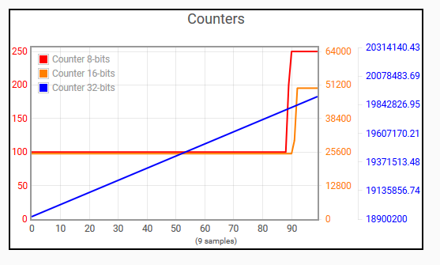

  - The 8-bit counter corresponds to variable **u8Counter** and it’s bound to token “**c1**”. It increments by 50 when switch S2 is pressed.
  - The 16-bit counter corresponds to variable **u16Counter** and it’s bound to token “**c2**”. It increments by 5,000 when switch S1 is pressed.
  - The 32-bit counter corresponds to variable **u32Counter** and it’s bound to token “**c3**”. It increments by 10,000 periodically on Timer interrupt
- The gauge shows a floating point number, which in this case is sent as fractional (QMath/IQMath)

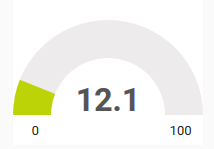

  - The counter corresponds to variable **qCounter** and it’s bound to token “**c4**”. It increments by **qIncrement** on Timer interrupt and only when bEnableSwitch==true.
- The increment for the gauge is set by the horizontal slider
  - The increments corresponds to variable **qIncrement** and it’s bound to token “**u16Data**”. The value is sent by the GUI to the device when the slider changes.
- The “Enable Float” switch enables incrementing the gauge increments
  - The switch corresponds to variable **bEnableSwitch** and it’s bound to token “**bEnable**”. The switch is sent by the GUI to the device when the value changes.

Notes:

- This example does not implement push-button debounce, so you might see multiple increments when pressing the button.
- The increments (50, 5000, 10000) are only meant to show the difference between variable type sizes.
- The example is sending ALL variables every time it wakes up due to button press or timer interrupt.
- It’s recommended to keep the tokens short, especially when sending them often. Longer tokens will result in longer transmission times.

# Additional Information

For more information on modifying the GUI and serial communication, please view the [GUI Composer User’s Guide](https://dev.ti.com/gc/v2/help/GC_UserGuide_v2/index.html).